# Study groups: HR and LR

The study’s own grouping. 25 people trained; each got a composite hypertrophy score; the 8 with the highest scores were profiled as higher responders (HR) and the 8 with the lowest as lower responders (LR). The middle 9 were not profiled. This is an extreme-groups design: the two groups sit far apart by construction, which makes a difference easier to see and makes any correlation computed across these 16 people stronger than it would be across all 25.

This step checks the labels against the phenotype and writes them in the same form as the clustering groupings, so every comparison downstream reads one kind of groups file.

## Packages

```r
library(here)
library(dplyr)
library(tibble)
library(purrr)
library(ggplot2)
source(here("00_Setup", "Shared_functions", "analysis_reporting_helpers.R"))
```

`phenotype.csv` holds one row per person: muscle and fibre cross-sectional area (mCSA, fCSA) and 1RM strength before and after training, the composite score and the training volume. `metadata.csv` maps each biopsy run to its person.

```r
out <- here("02_Groups", params$grouping, "c_data")
dir.create(out, recursive = TRUE, showWarnings = FALSE)
inputs <- c(
  phenotype = "00_Setup/Input/phenotype.csv",
  samples = "00_Setup/Input/metadata.csv"
)
paths <- map_chr(inputs, here)
stopifnot(file.exists(paths))
phenotype <- readr::read_csv(paths[["phenotype"]], show_col_types = FALSE)
samples <- readr::read_csv(paths[["samples"]], show_col_types = FALSE)
count(phenotype, arm)
```

```
# A tibble: 2 × 2
  arm       n
  <chr> <int>
1 HR        8
2 LR        8
```

## The composite score

The manuscript defines the composite as (2 × %ΔmCSA + %ΔfCSA) / 3, weighting whole-muscle growth twice as heavily as mixed fibre growth. Recomputed from the pre and post columns, it must match the `comp_hypertrophy` column the source supplied, up to the source’s rounding to two decimals.

```r
composite <- phenotype |>
  transmute(
    subject, arm,
    pct_mcsa = 100 * (mcsa_post_cm2 / mcsa_pre_cm2 - 1),
    pct_fcsa = 100 * (fcsa_mixed_post_um2 / fcsa_mixed_pre_um2 - 1),
    recomputed = (2 * pct_mcsa + pct_fcsa) / 3,
    comp_hypertrophy
  )
stopifnot(all(abs(composite$recomputed - composite$comp_hypertrophy) < 0.01 + 1e-9))
composite |>
  summarise(
    people = n(), mean = mean(comp_hypertrophy), sd = sd(comp_hypertrophy),
    lowest = min(comp_hypertrophy), highest = max(comp_hypertrophy), .by = arm
  )
```

```
# A tibble: 2 × 6
  arm   people  mean    sd lowest highest
  <chr>  <int> <dbl> <dbl>  <dbl>   <dbl>
1 HR         8 13.1   3.94   8.06   20.7
2 LR         8 -2.26  2.94  -6.6     0.85
```

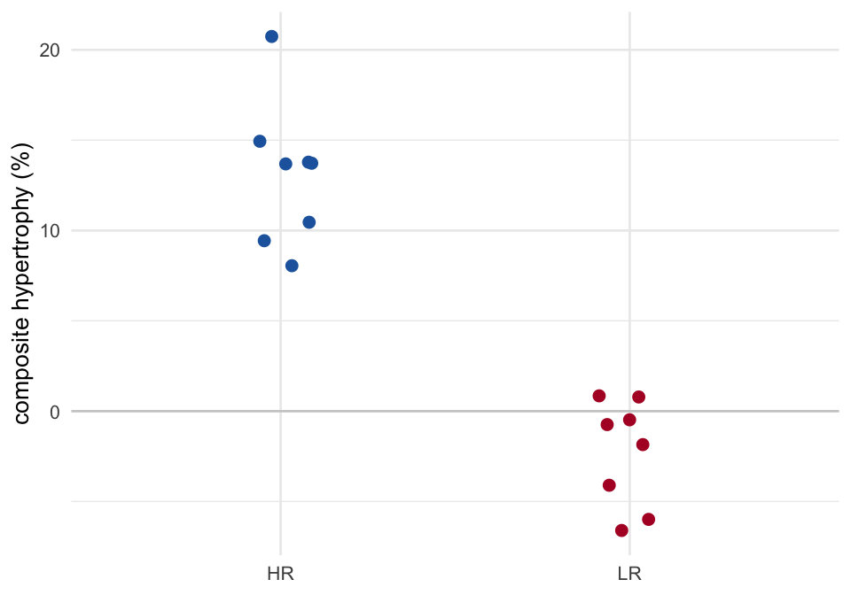

Figure 1: Composite score per person. The 9 unprofiled people sat in the gap.

```r
ggplot(composite, aes(arm, comp_hypertrophy, colour = arm)) +
  geom_hline(yintercept = 0, colour = "grey80") +
  geom_point(position = position_jitter(width = 0.1, seed = 1), size = 2) +
  scale_colour_manual(values = c(HR = "#2166AC", LR = "#B2182B"), guide = "none") +
  labs(x = NULL, y = "composite hypertrophy (%)") +
  theme_minimal(base_size = 10)
```

## Labels against the sample sheet

Every person in the phenotype table must carry the same label in the sample sheet.

```r
labels_in_samples <- distinct(samples, subject, arm)
arm_in_phenotype <- with(phenotype, set_names(arm, subject))
stopifnot(
  !anyDuplicated(labels_in_samples$subject),
  setequal(labels_in_samples$subject, phenotype$subject),
  all(labels_in_samples$arm == arm_in_phenotype[labels_in_samples$subject])
)
group_of <- with(labels_in_samples, set_names(arm, subject))
table(group_of)
```

```
group_of
HR LR
 8  8
```

## Summary

8 HR and 8 LR people. HR’s composite runs from 8.06 to 20.73%, LR’s from -6.6 to 0.85%. Because the composite defines the groups, a difference in muscle or fibre growth between HR and LR is built in and is not a finding; `comp_hypertrophy` stays out of the group-by-trait tests.

## Save

`groups.rds` holds who is in each group, the group order (the first group comes first in every contrast) and the traits that defined the groups.

```r
saveRDS(
  list(group_of = group_of, arms = c("HR", "LR"), defining_traits = "comp_hypertrophy"),
  file.path(out, "groups.rds")
)
write_workbook(
  list(composite = composite),
  "Per person: % change in mCSA and mixed fCSA, the recomputed composite and the source's.",
  file.path(out, "study_groups.xlsx"), inputs, paths
)
```